# Kodutöö 1 osa II

## Sissejuhatus

Mati “Raha” Masin töötab investeerimispangas ning ta vastutab igapäevase aktsiaturu ülevaate koostamise eest. Ta vihkab oma tööd selle rutiinsuse pärast. Vaja on kopeerida uued aktsiaturu andmed Exceli tabeli õigesse lahtrisse, klikkida vajalikel nuppudel ja kopeerida tulemused raportisse.

Peale selle, et tegevus on igav, võib andmete, valemite ja tulemuste kopeerimisel tekkida mitmeid vigu. Seega kontrollib Mati mitu korda üle ega kopeerimisel vigu ei tekkinud, sest ta teab, et andmete kopeerimisel võivad eksida isegi [Harvardi majandusteadlased](http://en.wikipedia.org/wiki/Growth_in_a_Time_of_Debt) (praktikum 2 teema).

Ta unistab automaatsest statistikaraportist - andmed ning analüüsi tulemused uuenevad automaatselt ja raporti genereerimine on automatiseeritud. Selles praktikumis vaatamegi, kuidas sellist tööprotsessi automatiseerida R-is.

Eesmärgiks on koostada automaatselt uuenev raport, kus on:

- suurimad tõusjad ja kukkujad;
- aktsiaturu ülevaade sektorite lõikes;
- aktsiate ostusoovitused.

Andmetabelist info kättesaamiseks kasutame R-i paketti *dplyr*. Selle paketi kohta loe täpsemalt praktikumimaterjalist ning uuri sealseid minimalistlikke näiteid.

## Ülevaade andmestikust

Andmestikus on näidatud 504 ettevõtte (kõik need ettevõtted, mis on kuulsas S&P 500 indeksis) kohta järgmised tunnused:

- *symbol*: ettevõtte ID börsil
- *nimi*: ettevõtte nimi
- *sektor*: sektor, kus ettevõte tegutseb
- *hind*: viimase aktsiatehingu hind
- *tootlus*: aktsiahinna muutus võrreldes eelmise päevaga protsentides
- *kogus*: aktsiate arv, mis vahetas omanikku päeva jooksul
- *kasum_aktsia_kohta*: ettevõtte aastakasum / aktsiate koguarv
- *dividend_aktsia_kohta*: väljamakstud dividendid aastas / aktsiate koguarv
- *aktsiate_arv*: näitab, kui palju aktsiaid on emiteeritud (st aktisate koguarv)

Laadi alla andmestik aktsiad.csv ning loe andmestik töökeskonda.

## Kodutöö raport

Kodutöö tulemusena peab valmima raport, kus kajastuvad järgnevate ülesannete lahendused. Allpool on toodud nii raportile esitatavad täpsemad nõuded (vt ülesanne 5) kui ka näidisraport. Ülesannete lahendamisel on vaja kasutada *dplyr* paketi funktsioone.

### Ülesanne 1 (3 punkti) - Suurimad tõusjad. Suurimad kukkujad.

> Mati tahab oma turuülevaates näidata kolme suurimat tõusjat ja kukkujat.

Kõigepealt leia kolm kõige suurema päevase tootlusega aktsiat ning väljasta nende kohta:

1. ettevõtte sümbol
2. ettevõtte nimi
3. tootlus.

Seejärel leia kolm kõige madalama päevase tootlusega aktsiat ning väljasta nende kohta samasugune info.

Näpunäide: Abiks on funktsioonid `arrange()`, `select()` ja `top_n()`.

### Ülesanne 2 (6 punkti) - Ülevaade sektorite lõikes

> Mati soovib raportis näidata ülevaadet ka sektorite lõikes, sest kliente võib huvitadada, kas ehitussektori aktsiatega kaubeldi rohkem kui IT-sektori aktsiatega?

Iga sektori kohta, kus on vähemalt 30 ettevõtet, väljasta järgnev info:

1. sektori keskmine tootlus
2. sektori kogukäive
3. sektori keskmine käive
4. ettevõtete arv sektoris

### Ülesanne 3 (5 punkti) - kauplemisalgoritm

> Mati arvates annab iga vähegi nupukam aktsiaanalüütik klientidele aktsiate ostusoovitusi, et klient saaks oma vara kasvatada.

Kirjuta funktsioon *kauplemisalgoritm*, mille sisendiks on andmestik *data* ja mis tagastab kolme kõige atraktiivsema ettevõtte sümbolid, mis saavadki ostusoovitusteks.

Juhised:

- Kõigepealt tekita andmestikku juurde järgmised kaks tunnust:
  - kasumi-aktsiahinna suhe (kasum_aktsia_kohta/hind) [kui sa tead, mida tähendab PE suhe, siis me arvutame PE suhte pöördväärtust]
  - dividendi määr (dividend_aktsia_kohta/hind)
- Arvuta iga aktsia kohta atraktiivsuse skoor, mis on arvutatud järgnevalt `0.5 * kasumi-aktsiahinna suhe + 0.5 * dividendi määr`
- Ostusoovituseks leia kolm kõige suurema skooriga aktsiat.

Kui eelnevaga oled hakkama saanud, siis proovi eelnev kood kirjutada funktsiooniks, mis võtab sisendiks suvalise andmestiku ning väljastab kolme kõige atraktiivsema ettevõtte aktsiate sümbolid **vektorina** (meenutus: `andmestik$tunnus`). Funktsioon võib välja näha näiteks nii:

```r
kauplemisalgoritm = function(x){
  # tekitame andmestikule x juurde tunnuse kasumi-aktsiahinna suhe ja dividendi määr
  # [sinu kood]

  # arvutame iga aktsia kohta atraktiivsuse skoori
  # [sinu kood]

  # tagasta kolme kõige suurema skooriga ettevõtte sümbolid vektorina
}
```

### Ülesanne 4 (2 punkti) - turvaline kauplemisalgoritm ja ostusoovitused

> Mati ei ole veel vanemanalüütiku staatust saanud ning ta kardab veidi oma soovituste pärast. Mis juhtub kui aktsiasoovitus osutub katastroofiks? Kui kliendid saavad Mati soovituste pärast hiigelsuuri kahjumeid, siis kõigub ka tema töökoht. Mis oleks kui soovitada ainult populaarseid aktsiaid? Siis saab ju alati öelda, et vanemanalüütikud teistes pankades soovitasid ka …

Nüüd kirjuta funktsioon *kauplemisalgoritm_turvaline*, kus valid atraktiivseid aktsiaid vaid populaarsete aktsiate hulgast. Populaarsed aktsiad on järgnevad: AAPL, FB, GOOG, IBM.

Juhised:

- Vali andmestikust välja ainult aktsiad AAPL, FB, GOOG, IBM.
- Rakenda saadud alamandmestikul eelnevas ülesandes kirjutatud funktsiooni.

Kui eelnev töötab, siis kirjuta eelnev kood funktsiooniks.

```r
kauplemisalgoritm_turvaline = function(x){
  # sinu kood
}
```

Kasutades funktsiooni *kauplemisalgoritm_turvaline*, väljasta 3 ostusoovitust.

### Ülesanne 5 (5 punkti) - raporti vormistamine

Vormistage eelnevate ülesannete lahendused selliseks *knitr* raportiks (html või pdf formaadis), et

- Kõik andmestike väljatrükid oleks toodud tabelitena (selleks kasuta näiteks funktsiooni `kable`).
- Ostusoovitus (ül 4 tulemus) lisage teksti sisse reasisese R-i koodi abil (*inline R code*).
- Ära raportis R-i koodi näita. Selleks kasuta näiteks `echo=FALSE` iga koodibloki jaoks või globaalset sätet, kus lisad `.Rmd` faili algusesse

````markdown
```{r, echo=FALSE}
library(knitr)
opts_chunk$set(echo=FALSE, message=FALSE)
```
````

### Näidisraport

Raport võiks välja näha umbes selline (pildil ei ole näidatud ilmtingimata õiged arvulised väärtused):

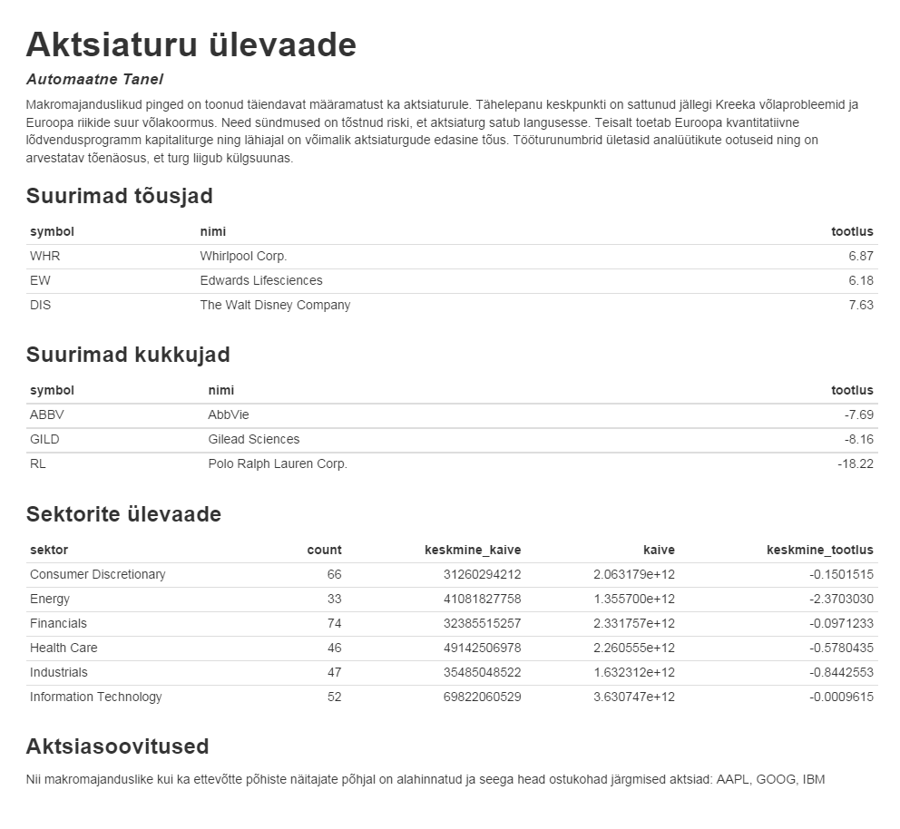

### Mida on vaja esitada?

Esitada tuleb nii raport (html või pdf formaadis) kui ka selle lähtekood .Rmd failina.

### Boonusülesanne 1 (1 punkt): raporti täiendamine

Mõtle välja ning lisa raportisse veel üks sektsioon, mis täiendaks Mati aktsiaturuülevaadet.

### Boonusülesanne 2 (3 punkti): andmete automaatne uuenemine

Muuda kodutööd selliselt, et staatilise faili *aktsiad.csv* asemel kasutatakse reaalajas andmeid, mis on saadud portaalist *finance.yahoo.com*.

Mõned näpunäited:

- kasuta R-i paketti `quantmod`
- kasuks tuleb funktsioon `getQuote`
- tunnuste loetelu nägemiseks, mida on võimalik *finance.yahoo.com* portaalist saada, on abiks funktsioon `yahooQF()`
- hinnana kasuta tunnust *Last Trade (Price Only)*, sümbolina *Symbol*, tootlusena *Change in Percent*, kogusena *Volume*, kasumina aktsia kohta *Earnings/Share*, dividendina aktsia kohta *Dividend/Share*
- ettevõtte *sektor*, *nimi* ja *aktsiate_arv* võta failist *aktsiad.csv*. Ühenda see alamandmestik Yahoo’st saadud andmestikuga tunnuse *symbol* alusel (vt`?join` või `?merge`)
- juhime tähelepanu, et tunnus *tootlus* vajab puhastamist